# 20230905_twoLine_model.R

2023-09-05

# Two-line model

Assume a model where the percentage of disease changes according to the addition of two lines. The first has a rate >= 0, the second with a rate <= 0 starts at some time after the initial time point of the first line.

(Currently, both lines use a first-order rate; an alternative model would be that the second effect depends on level at the given time point)

```r
rm(list=ls())
cat('\014')
```

```r
graphics.off()

suppressWarnings({      #no warnings to avoid cluttering Knit
library('tidyverse',quietly=TRUE,warn.conflicts = FALSE,verbose=FALSE)
library('rjags')
source('H:/My Drive/20230815_GlobBurdDisease/DBDA2E-utilities_mod.R')  #modified to fit markdown
source('H:/My Drive/20230815_GlobBurdDisease/20230905_twoLine_fit.R')
})
```

```
##
## Linked to JAGS 4.3.1
##
## Loaded modules: basemod,bugs
##
##
##
##
```

## Model visualization and SSQ parameter estimate

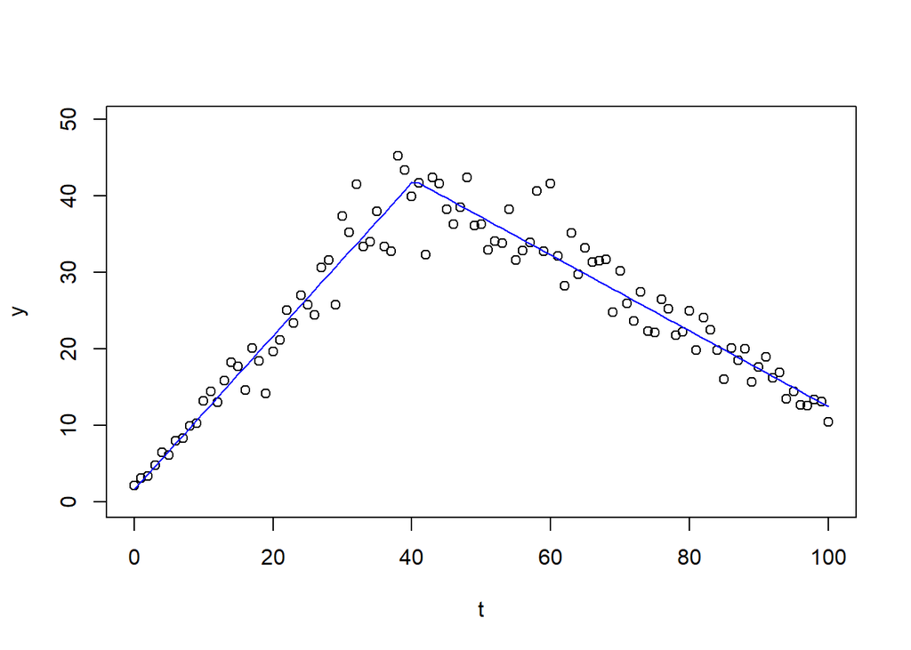

```r
set.seed(01092023)

a0=2
a1=1
a2= -1.5

t= 0:100
t0= 40

y_noNoise= a0 + a1*t + a2*ifelse(t>t0,t-t0,0)
#noise1= rnorm(length(t),mean=0,sd=1)  #constant noise level
noise2= rnorm(length(t),mean=0,sd=0.1*abs(y_noNoise))  #noise relative to data
y= y_noNoise+noise2
y[y<0]= 0   #make sure no negative values
DF= cbind.data.frame(t=t,y=y)

plot(t,y,ylim=c(0,1.1*max(y)))

twoLine_fun= function(t, pms, obs){  #ssq minimization between observed data
                                       #and two-line model
  a0= pms[1]; a1=pms[2]; a2=pms[3]; t0= pms[4]
  y= a0 + a1*t + a2*ifelse(t>t0,t-t0,0)

  ssq= sum( (obs-y)^2 )
  return(ssq)
}

pms= c(a0,a1,a2,t0)
#twoLine_fun(t,pms,obs=y)

nlmOUT= nlm(f=twoLine_fun,p=c(a0=0,a1=1,a2=1,t0=max(t)/2),t=t,obs=y)
est= nlmOUT$estimate

lines(t, est[1] + est[2]*t + est[3]*ifelse(t>est[4],t-est[4],0),col='blue')
```

# Estimate parameters based on Bayesian model

```r
modStr=
'
data{
  #Ntotal= length(y)
   #transform data by rescaling y and shifting t to t1/2
    t_half= (max(t)-min(t))/2
    mean_y= mean(y)
    sd_y= sd(y)
    for(i in 1:Ntotal){
      t_z[i]= t[i]-t_half
      y_z[i]= (y[i]-mean_y)/sd_y
    }
}

model{
  for(i in 1:Ntotal){
    t2[i]= ifelse(t_z[i]>t0_z,t_z[i]-t0_z,0)  #only subtracted if t_z[i]>t0_z
    y_z[i] ~ dnorm( a0 + a1*t_z[i] + a2*t2[i], 1/sig_y^2 ) #homog. variance
  }
   #priors
   a0 ~ dnorm(0,1)      #orig. scale mean= mean_y

   #Prior for a1 has tail in the right and for a2 in the left direction ->
    #it is clear which is the positive and which the negative slope
   #To allow parameter estimates of 0, shift them so that the mean of each
    #prior is at 0
   #(cases with only small slopes will have high autocorrelation)
   a1_shift ~ dgamma(.05,2)     #orig. scale mean= 0.025*sd_y, ESS= 2
   a1= a1_shift-0.025  #mean at 0
   a2 = -a2_neg_shift+0.025         #ensure a2 is negative on same scale as a1
   a2_neg_shift~ dgamma(.05,2)

   t0_z= t0-t_half
   t0 ~ dunif(0,2*t_half)  #t0 anywhere between 0 and max(t)
   sig_y ~ dgamma(1/10,1) #on transformed scale

   #re-transform
   b0= a0*sd_y - a1*sd_y*t_half + mean_y
   b1= a1*sd_y
   b2= a2*sd_y
}'

#y=c(); t=c()  #if you want priors
dataList= list(
  t= t,
  y= y,
  Ntotal= length(y)
)

jagMod= jags.model(file=textConnection(modStr),data=dataList,n.chains=3)
```

```
## Compiling data graph
##    Initializing
##    Reading data back into data table
##
```

```r
cS= coda.samples(model=jagMod,variable.names = c('b0','b1','b2','t0'),n.iter=10000)

#diagnostics
for(i in 1:length(varnames(cS))){
  diagMCMC(codaObject= cS,parName=varnames(cS)[i]  )
}
```

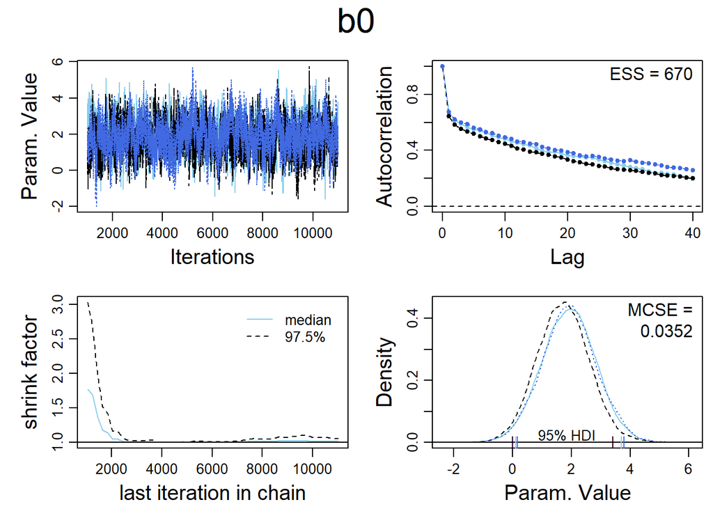

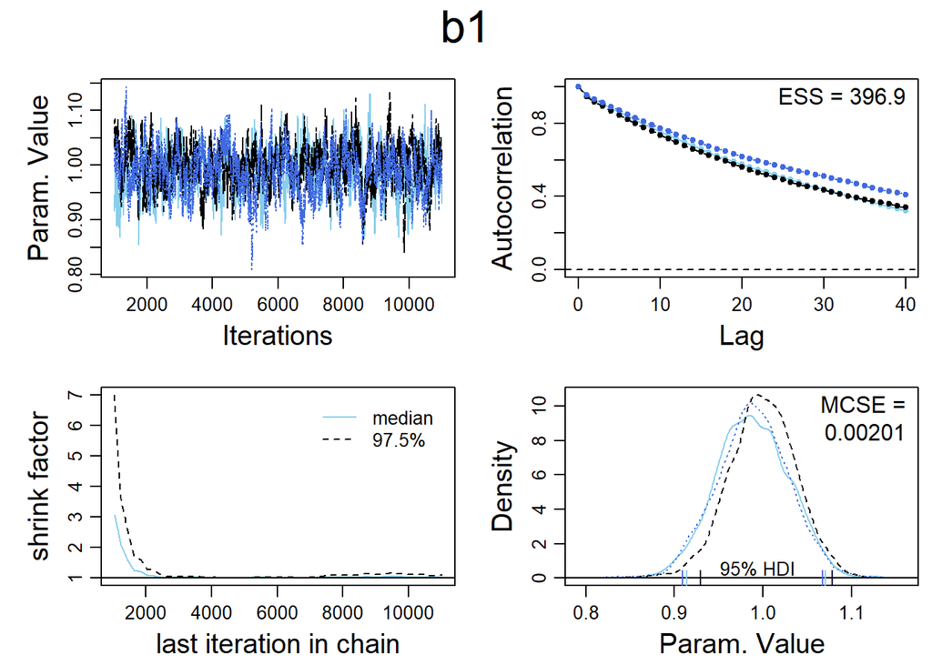

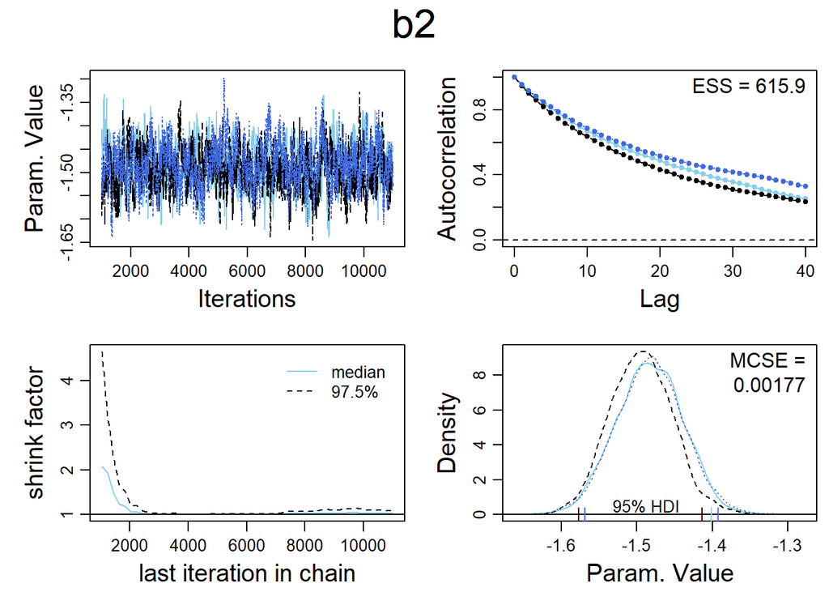

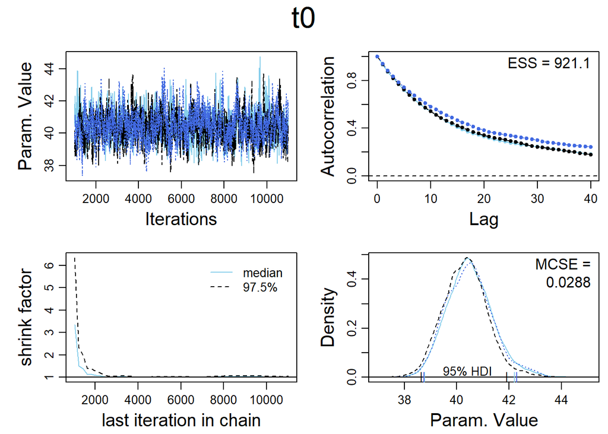

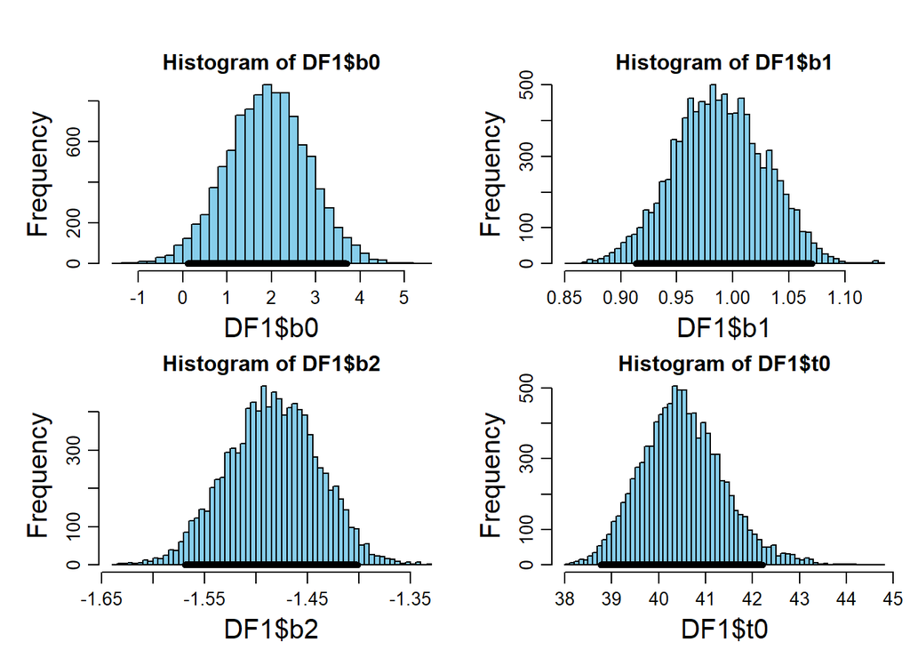

```r
# MCMC results
DF1= data.frame(cS[[1]])
#head(DF1)
par(mfrow=c(2,2))
hist(DF1$b0,col='skyblue',breaks=50)
lines(x=HDIofMCMC(DF1$b0,credMass=.95),y=c(0,0),lwd=5)

hist(DF1$b1,col='skyblue',breaks=50)
lines(x=HDIofMCMC(DF1$b1,credMass=.95),y=c(0,0),lwd=5)

hist(DF1$b2,col='skyblue',breaks=50)
lines(x=HDIofMCMC(DF1$b2,credMass=.95),y=c(0,0),lwd=5)

hist(DF1$t0,col='skyblue',breaks=50)
lines(x=HDIofMCMC(DF1$t0,credMass=.95),y=c(0,0),lwd=5)
```

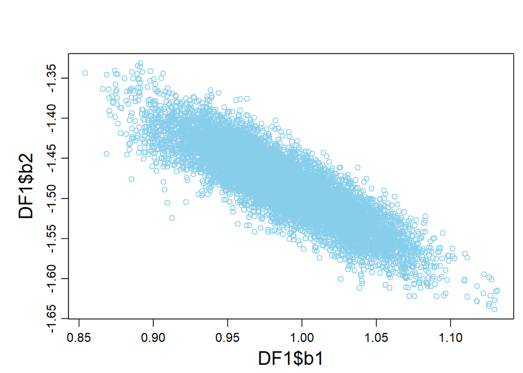

```r
par(mfrow=c(1,1))
plot(DF1$b1,DF1$b2,col='skyblue')
```